# Performance Evaluation of Data Balancing Techniques for Imbalanced Classification

This project investigates the impact of different data balancing techniques on imbalanced classification problems. The performance of a Random Forest classifier is evaluated using the original dataset, SMOTE oversampling, DBSMOTE oversampling, Random Undersampling, and Cost-Sensitive Random Forest without data preprocessing. The results are compared using multiple evaluation metrics to determine the most effective approach for handling class imbalance.

# About Me

## Wessam Abo Zayed

**Automation Engineering · PLC Programming · Data Analyst**

- Computer Scientist with a focus on Automation Engineering, PLC Programming, and Data Analytics. I combine technical expertise with analytical problem-solving skills to develop practical and efficient solutions for industrial automation systems and data-driven applications.

## Kontakt

| Plattform | Link |
| --- | --- |
| **E-Mail** | abozayed.wessam@gmail.com |
| **LinkedIn** | [linkedin.com/in/wessam-abozayed](https://www.linkedin.com/in/wessam-abozayed/) |
| **GitHub** | github.com/wessam-abo-zayed |
| **Tableau Public** | public.tableau.com/app/profile/wessam3726 |

### Introduction:

- In this artical we will exploring performance measures for imbalance dataset "Card Fraud Detection" data, we will use the random forest classifier to detect credit frauds from the dataset, with the following specifications:
  - Baseline training with the original data.
  - SMOTE oversampling on the data.
  - DBSMOTE oversampling on the data.
  - Random undersampling on the data.
  - Without data preprocessing (oversampling or undersampling).

### Exploring the data:

```python
import numpy as np
import pandas as pd
import matplotlib.pyplot as plt
from sklearn.model_selection import train_test_split

df = pd.read_csv('data/creditcard.csv')
df.head(3)
```

|  | Time | V1 | V2 | V3 | V4 | V5 | V6 | V7 | V8 | V9 | ... | V21 | V22 | V23 | V24 | V25 | V26 | V27 | V28 | Amount | Class |
| --- | --- | --- | --- | --- | --- | --- | --- | --- | --- | --- | --- | --- | --- | --- | --- | --- | --- | --- | --- | --- | --- |
| 0 | 0.0 | -1.359807 | -0.072781 | 2.536347 | 1.378155 | -0.338321 | 0.462388 | 0.239599 | 0.098698 | 0.363787 | ... | -0.018307 | 0.277838 | -0.110474 | 0.066928 | 0.128539 | -0.189115 | 0.133558 | -0.021053 | 149.62 | 0 |
| 1 | 0.0 | 1.191857 | 0.266151 | 0.166480 | 0.448154 | 0.060018 | -0.082361 | -0.078803 | 0.085102 | -0.255425 | ... | -0.225775 | -0.638672 | 0.101288 | -0.339846 | 0.167170 | 0.125895 | -0.008983 | 0.014724 | 2.69 | 0 |
| 2 | 1.0 | -1.358354 | -1.340163 | 1.773209 | 0.379780 | -0.503198 | 1.800499 | 0.791461 | 0.247676 | -1.514654 | ... | 0.247998 | 0.771679 | 0.909412 | -0.689281 | -0.327642 | -0.139097 | -0.055353 | -0.059752 | 378.66 | 0 |

3 rows × 31 columns

```python
# get the shape "Columns" & "Rows"
print("Number of samples 'rows'  : ", df.shape[0]  )
print("Number of 'Columns'       : ", df.shape[1]  )
print("Number of 'Features'      : ", df.shape[1] - 1 )
print("The    Label is 'Class'. ")
```

```
Number of samples 'rows'  :  284807
Number of 'Columns'       :  31
Number of 'Features'      :  30
The    Label is 'Class'.
```

```
--------------------------
0    284315
1       492
Name: Class, dtype: int64
---------------------------
```

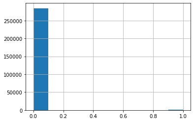

```python
df['Class'].hist()
print("--------------------------")
print(df['Class'].value_counts())
print("---------------------------")
```

- as shown the data is imbalanced class "0" has 284315 sample, and class "1" has 492.

## General variable & Functions:

```python
accuracy_data = {'Accuracy'                     :[],
                 'Balanced accuracy'            :[],
                 'Precision'                    :[],
                 'Recall'                       :[],
                 'F1-Score'                     :[],
                 'G-Mean'                       :[],
                 'Kappa Score'                  :[],
                 'AUC score'                    :[],
                 'Average Precision Score (APS)':[],}
```

```python
#Import scikit-learn metrics module for accuracy calculation
from sklearn.metrics import accuracy_score, balanced_accuracy_score, precision_score , recall_score, f1_score, cohen_kappa_score, roc_auc_score, average_precision_score
from imblearn.metrics import geometric_mean_score

def accuracy_function(Case_Name , y_test_name , y_pred_name):
    print("     "+ Case_Name +"  ")
    print("--------------------------------------------------")
    # Model Accuracy:
    accuracy_score_name = accuracy_score(y_test_name , y_pred_name)
    accuracy_data['Accuracy'].append(accuracy_score_name)
    print("- Accuracy                     :", accuracy_score_name)
    print("--------------------------------------------------")
    # Model Balanced Accuracy:
    balanced_accuracy_name = balanced_accuracy_score(y_test_name , y_pred_name)
    accuracy_data['Balanced accuracy'].append(balanced_accuracy_name)
    print("- Balanced Accuracy            :", balanced_accuracy_name)
    print("--------------------------------------------------")
    # Model Precision Accuracy:
    precision_score_name = precision_score(y_test_name , y_pred_name)
    accuracy_data['Precision'].append(precision_score_name)
    print("- Precision                    :",precision_score_name)
    print("--------------------------------------------------")
    # Model Recall Accuracy:
    recall_score_name = recall_score(y_test_name , y_pred_name)
    accuracy_data['Recall'].append(recall_score_name)
    print("- Recall                       :",recall_score_name)
    print("--------------------------------------------------")
    # Model F1-Score Accuracy:
    f1_score_name = f1_score(y_test_name , y_pred_name)
    accuracy_data['F1-Score'].append(f1_score_name)
    print("- F1-Score                     :",f1_score_name)
    print("--------------------------------------------------")
    # Model G-Mean Accuracy:
    geometric_mean_score_name = geometric_mean_score(y_test_name , y_pred_name)
    accuracy_data['G-Mean'].append(geometric_mean_score_name)
    print("- G-Mean                       :",geometric_mean_score_name)
    print("--------------------------------------------------")
    # Model Kappa Score Accuracy:
    cohen_kappa_score_name = cohen_kappa_score(y_test_name , y_pred_name)
    accuracy_data['Kappa Score'].append(cohen_kappa_score_name)
    print("- Kappa Score                  :",cohen_kappa_score_name)
    print("--------------------------------------------------")
    # Model AUC score Accuracy:
    roc_auc_score_name = roc_auc_score(y_test_name , y_pred_name)
    accuracy_data['AUC score'].append(roc_auc_score_name)
    print("- AUC score                    :",roc_auc_score_name)
    print("--------------------------------------------------")
    # Model Average Precision Score (APS) Accuracy:
    average_precision_score_name = average_precision_score(y_test_name , y_pred_name)
    accuracy_data['Average Precision Score (APS)'].append(average_precision_score_name)
    print("- Average Precision Score (APS):",average_precision_score_name)
    print("--------------------------------------------------")
```

```python
def drow_function_1(index , name):
    acc = list(accuracy_data.keys())
    values = [accuracy_data[i][index] for i in accuracy_data]

    fig = plt.figure(figsize = (10, 5))

    # creating the bar plot
    plt.bar(acc, values, color ='green',width = 0.4)

    plt.xlabel("performance measures")
    plt.ylabel("Accuracy")
    plt.title(name)
    plt.xticks(rotation=45)
    plt.show()
```

```python
import matplotlib.pyplot as plt
import numpy as np
def drow_function_2(ii):
    fig  = plt.subplots(1, 3, figsize=(18, 5))
    ##########################################
    acc = ['AUC score:'                    + str(round(accuracy_data['AUC score'][ii]*100,2)),
           'Average Precision Score (APS):'+ str(round(accuracy_data['Average Precision Score (APS)'][ii]*100,2))]
    values = [accuracy_data['AUC score'][ii],accuracy_data['Average Precision Score (APS)'][ii]]
    plt.bar(acc, values, color ='green',width = 0.4)
    plt.xlabel("performance measures")
    plt.ylabel("Accuracy")
    plt.title("AUC vs APS")
    plt.subplot(131)
    ##########################################
    acc = ['F1-Score:'+ str(round(accuracy_data['F1-Score'][ii]*100,2)),
           'Kappa Score:'+ str(round(accuracy_data['Kappa Score'][ii]*100,2))]
    values = [accuracy_data['F1-Score'][ii],accuracy_data['Kappa Score'][ii]]
    plt.bar(acc, values, color ='red',width = 0.4)
    plt.xlabel("performance measures")
    plt.ylabel("Accuracy")
    plt.title("F1-Score VS Kappa Score")
    plt.subplot(132)
    ##########################################
    acc = ['F1-Score:'+ str(round(accuracy_data['F1-Score'][ii]*100,2)),
           'G-Mean:  '+ str(round(accuracy_data['G-Mean'][ii]*100,2))]
    values = [accuracy_data['F1-Score'][ii],accuracy_data['G-Mean'][ii]]
    plt.bar(acc, values, color ='blue',width = 0.4)
    plt.xlabel("performance measures")
    plt.ylabel("Accuracy")
    plt.title("F1-Score vs G-Mean")
    plt.subplot(133)
    ###########################################
```

```python
def Scatter_plot(x , y):
    c1 = plt.scatter(x[y==0]['Time'],x[y==0]["Amount"], marker='o', color='b')
    c2 = plt.scatter(x[y==1]['Time'],x[y==1]["Amount"], marker='o', color="y")
    plt.xlabel("Time")
    plt.ylabel("Amount")
    plt.title("Scatter points")

    plt.legend((c1,c2),
           ('Class 0', 'Class1'),
           scatterpoints=1,
           loc='upper center',
           ncol=3,
           fontsize=8)
    plt.show()
```

### 1- First case:

- Baseline training with the original data:

```python
X1 = df.loc[:,df.columns!="Class"] # "Features"
y1 = df['Class']  # Labels

# Split dataset into training set and test set
X_train1, X_test1, y_train1, y_test1 = train_test_split(X1, y1, test_size=0.2  ) # Train Test split (80:20).
```

```python
#Import Random Forest Model
from sklearn.ensemble import RandomForestClassifier
#Create a Gaussian Classifier
model1 = RandomForestClassifier()
#Train the model using the training sets.
model1.fit(X_train1,y_train1)

y_pred1 = model1.predict(X_test1)
```

```python
accuracy_function("Baseline training with the original data" , y_test1, y_pred1)
```

```
     Baseline training with the original data
--------------------------------------------------
- Accuracy                     : 0.9997015554229135
--------------------------------------------------
- Balanced Accuracy            : 0.9195138562586838
--------------------------------------------------
- Precision                    : 0.9605263157894737
--------------------------------------------------
- Recall                       : 0.8390804597701149
--------------------------------------------------
- F1-Score                     : 0.8957055214723926
--------------------------------------------------
- G-Mean                       : 0.9159891923931353
--------------------------------------------------
- Kappa Score                  : 0.895556766903426
--------------------------------------------------
- AUC score                    : 0.9195138562586838
--------------------------------------------------
- Average Precision Score (APS): 0.8062046405609385
--------------------------------------------------
```

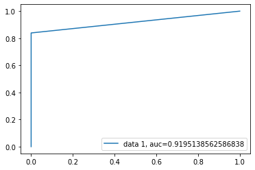

```python
# ROC Curve
from sklearn import metrics
import matplotlib.pyplot as plt
y_pred_proba = model1.predict_proba(X_test1)[::,1]
fpr, tpr, _ = metrics.roc_curve(y_test1, y_pred1)
auc = metrics.roc_auc_score(y_test1, y_pred1)
plt.plot(fpr,tpr,label="data 1, auc="+str(auc))
plt.legend(loc=4)
plt.show()
```

### Compare between performance measures for the first case "Baseline training with the original data":

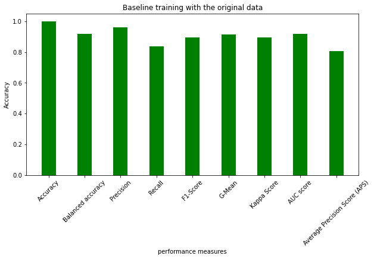

```python
drow_function_1(0 , "Baseline training with the original data")
```

- ## F1-Score vs G-mean , F1-Score vs Kappa Score , AUC vs APS :

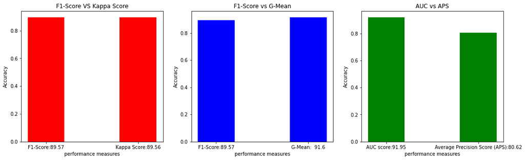

```python
drow_function_2(0)
```

### 2- Second case:

- SMOTE oversampling on the data

```python
from collections import Counter
from imblearn.over_sampling import SMOTE
from numpy import where

X2 = df.loc[:,df.columns!="Class"] # "Features"
y2 = df['Class']  # Labels
```

```python
# summarize class distribution
counter2 = Counter(y2)
print(counter2)
```

```
Counter({0: 284315, 1: 492})
```

```python
Scatter_plot(X2,y2)
```

[output not shown]

- ## SMOTE oversampling on the data:

```python
oversample = SMOTE()
X2, y2 = oversample.fit_resample(X2, y2)
```

- ## We will notice that the data became balaced:

```python
counter = Counter(y2)
print(counter)
```

```
Counter({0: 284315, 1: 284315})
```

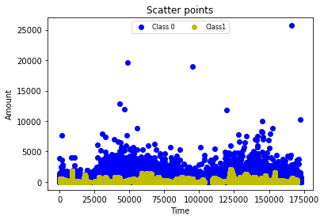

```python
Scatter_plot(X2,y2)
```

```python
 # Split dataset into training set and test set
X_train2, X_test2, y_train2, y_test2 = train_test_split(X2, y2, test_size=0.2  ) # Train Test split (80:20).
```

```python
#Import Random Forest Model
from sklearn.ensemble import RandomForestClassifier
#Create a Gaussian Classifier
model2 = RandomForestClassifier()
#Train the model using the training sets.
model2.fit(X_train2,y_train2)

y_pred2 = model2.predict(X_test2)
```

```python
accuracy_function("SMOTE oversampling on the data" , y_test2, y_pred2)
```

```
     SMOTE oversampling on the data
--------------------------------------------------
- Accuracy                     : 0.9999560346798445
--------------------------------------------------
- Balanced Accuracy            : 0.9999560540008438
--------------------------------------------------
- Precision                    : 0.9999120384216175
--------------------------------------------------
- Recall                       : 1.0
--------------------------------------------------
- F1-Score                     : 0.9999560172764138
--------------------------------------------------
- G-Mean                       : 0.9999560530351759
--------------------------------------------------
- Kappa Score                  : 0.9999120693460919
--------------------------------------------------
- AUC score                    : 0.9999560540008438
--------------------------------------------------
- Average Precision Score (APS): 0.9999120384216175
--------------------------------------------------
```

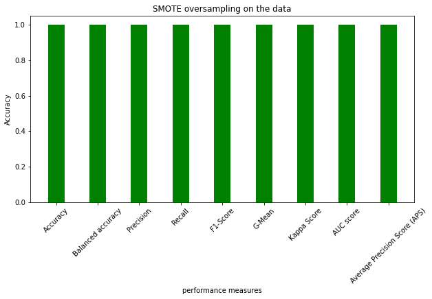

```python
drow_function_1(1 , "SMOTE oversampling on the data")
```

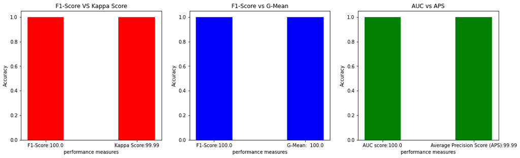

```python
drow_function_2(1)
```

### 3- Third case:

- DBSMOTE oversampling on the data

```python
# Installing smote_variants:
# https://smote-variants.readthedocs.io/en/latest/installation.html
# required: joblib,numpy,pandas,sklearn,scipy,minisom,keras
# https://github.com/analyticalmindsltd/smote_variants
# cd smote_variants-master
# !pip install .
#!pip install metric-learn
```

```python
cd smote_variants-master
```

```
C:\Users\Wessam\Desktop\AI Ceminar\2022\Nour        (CS10) -  Performance measures on imbalance datasets\smote_variants-master
```

```python
pwd
```

```
'C:\\Users\\Wessam\\Desktop\\AI Ceminar\\2022\\Nour        (CS10) -  Performance measures on imbalance datasets\\smote_variants-master'
```

```python
import smote_variants as sv
from smote_variants import DBSMOTE
from collections import Counter
```

```python
cd ..
```

```
C:\Users\Wessam\Desktop\AI Ceminar\2022\Nour        (CS10) -  Performance measures on imbalance datasets
```

```python
X3 = df.loc[:,df.columns!="Class"] # "Features"
y3 = df['Class']  # Labels
```

```python
# summarize class distribution
counter3 = Counter(y3)
print(counter3)
```

```
Counter({0: 284315, 1: 492})
```

```python
Scatter_plot(X3,y3)
```

[output not shown]

- ## DBSMOTE oversampling on the data:

```python
oversample3 = DBSMOTE()
X3, y3 = oversample3.fit_resample(X3, y3)
```

[output not shown]

```python
counter3 = Counter(y3)
print(counter3)
```

```
Counter({0: 284315, 1: 284315})
```

```python
# Split dataset into training set and test set
X_train3, X_test3, y_train3, y_test3 = train_test_split(X3, y3, test_size=0.2  ) # Train Test split (80:20).
```

```python
#Import Random Forest Model
from sklearn.ensemble import RandomForestClassifier
#Create a Gaussian Classifier
model3 = RandomForestClassifier()
#Train the model using the training sets.
model3.fit(X_train3,y_train3)

y_pred3 = model3.predict(X_test3)
```

```python
accuracy_function("DBSMOTE oversampling on the data" , y_test3, y_pred3)
```

```
     DBSMOTE oversampling on the data
--------------------------------------------------
- Accuracy                     : 0.9997098288869739
--------------------------------------------------
- Balanced Accuracy            : 0.9997091066385445
--------------------------------------------------
- Precision                    : 0.9998763250883392
--------------------------------------------------
- Recall                       : 0.9995407901941045
--------------------------------------------------
- F1-Score                     : 0.9997085294871002
--------------------------------------------------
- G-Mean                       : 0.9997090924692099
--------------------------------------------------
- Kappa Score                  : 0.9994196462559014
--------------------------------------------------
- AUC score                    : 0.9997091066385445
--------------------------------------------------
- Average Precision Score (APS): 0.9996457917399842
--------------------------------------------------
```

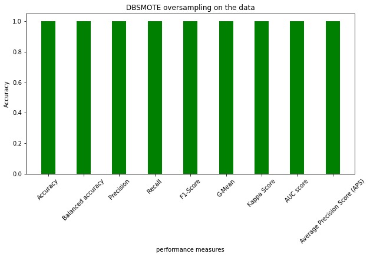

```python
drow_function_1(2 , "DBSMOTE oversampling on the data")
```

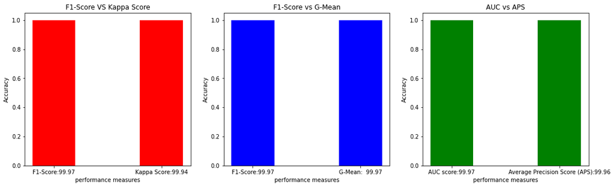

```python
drow_function_2(2)
```

### 4- Fourth case:

- Random undersampling on the data

```python
X4 = df.loc[:,df.columns!="Class"] # "Features"
y4 = df['Class']  # Labels
```

```python
counter4 = Counter(y4)
print(counter4)
```

```
Counter({0: 284315, 1: 492})
```

```python
Scatter_plot(X4,y4)
```

[output not shown]

- ## Random undersampling:

```python
from imblearn.under_sampling import RandomUnderSampler
undersample4 = RandomUnderSampler(sampling_strategy='majority')
X4, y4 = undersample4.fit_resample(X4, y4)
```

```python
counter4 = Counter(y4)
print(counter4)
```

```
Counter({0: 492, 1: 492})
```

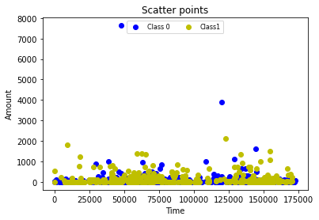

```python
Scatter_plot(X4,y4)
```

```python
# Split dataset into training set and test set
X_train4, X_test4, y_train4, y_test4 = train_test_split(X4, y4, test_size=0.2  ) # Train Test split (80:20).
```

```python
#Import Random Forest Model
from sklearn.ensemble import RandomForestClassifier
#Create a Gaussian Classifier
model4 = RandomForestClassifier()
#Train the model using the training sets.
model4.fit(X_train4,y_train4)

y_pred4 = model4.predict(X_test4)
```

```python
accuracy_function("Random undersampling on the data" , y_test4, y_pred4)
```

```
     Random undersampling on the data
--------------------------------------------------
- Accuracy                     : 0.9746192893401016
--------------------------------------------------
- Balanced Accuracy            : 0.9742268041237113
--------------------------------------------------
- Precision                    : 1.0
--------------------------------------------------
- Recall                       : 0.9484536082474226
--------------------------------------------------
- F1-Score                     : 0.9735449735449735
--------------------------------------------------
- G-Mean                       : 0.9738858291644984
--------------------------------------------------
- Kappa Score                  : 0.949187516120712
--------------------------------------------------
- AUC score                    : 0.9742268041237113
--------------------------------------------------
- Average Precision Score (APS): 0.9738343189073211
--------------------------------------------------
```

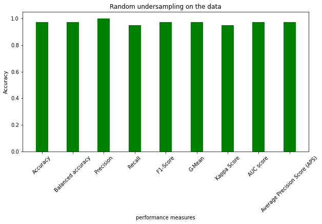

```python
drow_function_1(3 , "Random undersampling on the data")
```

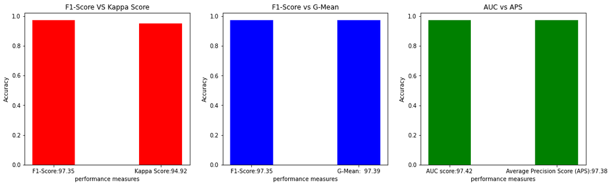

```python
drow_function_2(3)
```

### 5- Fifth case:

- Without data preprocessing (using cost sensitive random forest)

```python
X5 = df.loc[:,df.columns!="Class"] # "Features"
y5 = df['Class']  # Labels
```

```python
Scatter_plot(X5,y5)
```

[output not shown]

```python
counter5 = Counter(y5)
print(counter5)
```

```
Counter({0: 284315, 1: 492})
```

```python
# Split dataset into training set and test set
X_train5, X_test5, y_train5, y_test5 = train_test_split(X5, y5, test_size=0.2  ) # Train Test split (80:20).
```

```python
from sklearn.ensemble import RandomForestClassifier
class_weight = dict({0:1, 1:100})
model5 = RandomForestClassifier(class_weight=class_weight)

model5.fit(X_train5,y_train5)

y_pred5 = model5.predict(X_test5)
```

```python
accuracy_function("Without data preprocessing" , y_test5, y_pred5)
```

```
     Without data preprocessing
--------------------------------------------------
- Accuracy                     : 0.9994908886626171
--------------------------------------------------
- Balanced Accuracy            : 0.8627363045112523
--------------------------------------------------
- Precision                    : 0.9866666666666667
--------------------------------------------------
- Recall                       : 0.7254901960784313
--------------------------------------------------
- F1-Score                     : 0.8361581920903954
--------------------------------------------------
- G-Mean                       : 0.8517496327218337
--------------------------------------------------
- Kappa Score                  : 0.8359091818455079
--------------------------------------------------
- AUC score                    : 0.8627363045112524
--------------------------------------------------
- Average Precision Score (APS): 0.7163085492380771
--------------------------------------------------
```

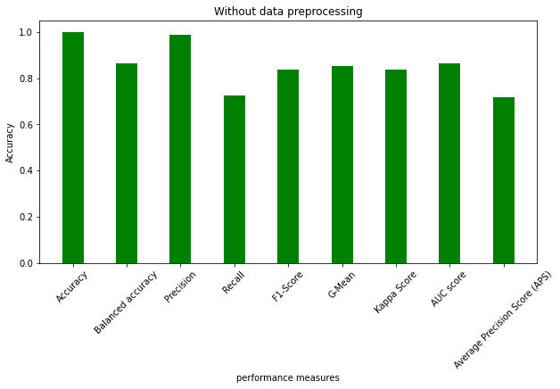

```python
drow_function_1(4 , "Without data preprocessing")
```

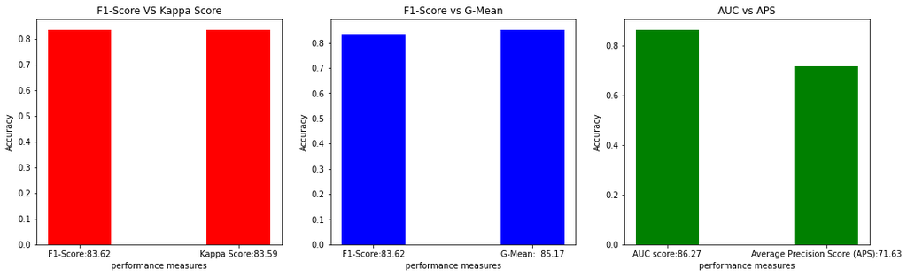

```python
drow_function_2(4)
```

- ### Creates pandas DataFrame.

```python
df_result = pd.DataFrame(accuracy_data, index=['Baseline',
                                               'SMOTE',
                                               'DBSMOTE',
                                               'Random undersampling',
                                               'cost sensitive RF'])

# print the data
df_result
```

|  | Accuracy | Balanced accuracy | Precision | Recall | F1-Score | G-Mean | Kappa Score | AUC score | Average Precision Score (APS) |
| --- | --- | --- | --- | --- | --- | --- | --- | --- | --- |
| Baseline | 0.999702 | 0.919514 | 0.960526 | 0.839080 | 0.895706 | 0.915989 | 0.895557 | 0.919514 | 0.806205 |
| SMOTE | 0.999956 | 0.999956 | 0.999912 | 1.000000 | 0.999956 | 0.999956 | 0.999912 | 0.999956 | 0.999912 |
| DBSMOTE | 0.999710 | 0.999709 | 0.999876 | 0.999541 | 0.999709 | 0.999709 | 0.999420 | 0.999709 | 0.999646 |
| Random undersampling | 0.974619 | 0.974227 | 1.000000 | 0.948454 | 0.973545 | 0.973886 | 0.949188 | 0.974227 | 0.973834 |
| cost sensitive RF | 0.999491 | 0.862736 | 0.986667 | 0.725490 | 0.836158 | 0.851750 | 0.835909 | 0.862736 | 0.716309 |

- ### Save resulte as csv file:

```python
# saving the dataframe
df_result.to_csv('results.csv')
```

- ### read the data:

```python
# read the result dataframe
df_result_acc = pd.read_csv('results.csv')
df_result_acc.rename(columns = {'Unnamed: 0':'Case Study'}, inplace = True)
df_result_acc
```

|  | Case Study | Accuracy | Balanced accuracy | Precision | Recall | F1-Score | G-Mean | Kappa Score | AUC score | Average Precision Score (APS) |
| --- | --- | --- | --- | --- | --- | --- | --- | --- | --- | --- |
| 0 | Baseline | 0.999702 | 0.919514 | 0.960526 | 0.839080 | 0.895706 | 0.915989 | 0.895557 | 0.919514 | 0.806205 |
| 1 | SMOTE | 0.999956 | 0.999956 | 0.999912 | 1.000000 | 0.999956 | 0.999956 | 0.999912 | 0.999956 | 0.999912 |
| 2 | DBSMOTE | 0.999710 | 0.999709 | 0.999876 | 0.999541 | 0.999709 | 0.999709 | 0.999420 | 0.999709 | 0.999646 |
| 3 | Random undersampling | 0.974619 | 0.974227 | 1.000000 | 0.948454 | 0.973545 | 0.973886 | 0.949188 | 0.974227 | 0.973834 |
| 4 | cost sensitive RF | 0.999491 | 0.862736 | 0.986667 | 0.725490 | 0.836158 | 0.851750 | 0.835909 | 0.862736 | 0.716309 |

- ### Draw chart to compare each measure in all 5 cases:

```python
def result_draw_func(measures):
    ax = df_result_acc.plot(x= 'Case Study', y= measures , kind="bar")
    ax.bar_label(ax.containers[0], labels=round(df_result_acc[measures]*100,2))
    ax.get_legend().remove()
    plt.xlabel("performance measures")
    plt.ylabel("Accuracy")
    plt.title(measures)
    plt.xticks(rotation=45)
    plt.show()
```

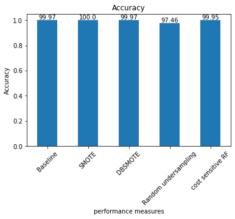

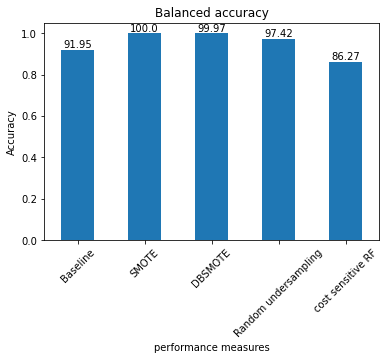

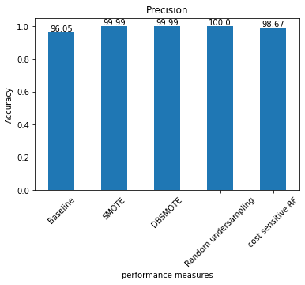

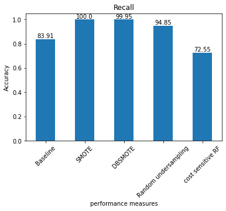

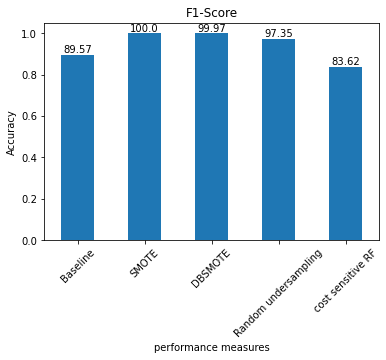

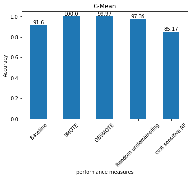

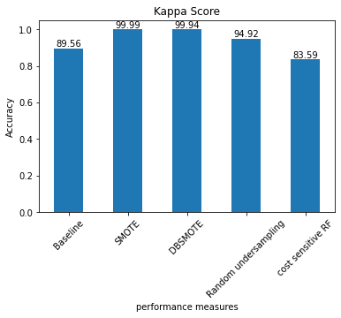

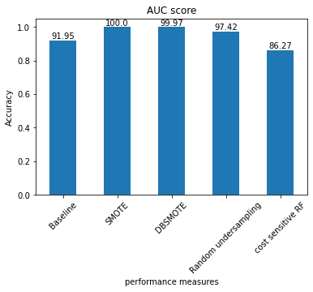

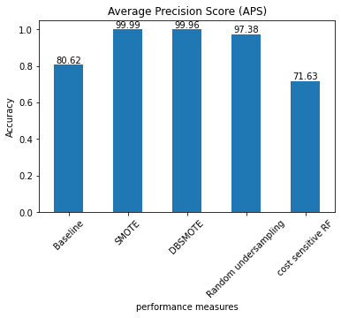

```python
col = list(df_result_acc)[1:]
for i in col:
    result_draw_func(i)
```

- ### F1-Score vs G-mean:

```python
def compare_between_measures(measures_listb):
    ax = df_result_acc.plot(x= 'Case Study', y= measures_listb , kind="bar")
    ax.bar_label(ax.containers[0], labels=round(df_result_acc[measures_listb[0]]*100,2), color = "green",rotation=45)
    ax.bar_label(ax.containers[1], labels=round(df_result_acc[measures_listb[1]]*100,2), color = "red",rotation=45)
    plt.legend(loc='lower center')
    plt.xlabel("performance measures")
    plt.ylabel("Accuracy")
    plt.xticks(rotation=45)
    plt.show()
```

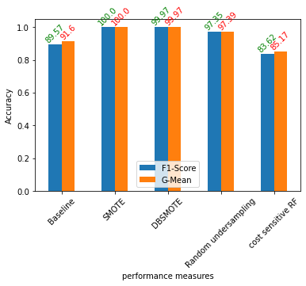

```python
compare_between_measures(["F1-Score","G-Mean"])
```

- ### F1-Score vs Kappa Score:

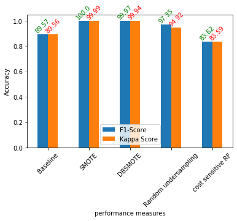

```python
compare_between_measures(["F1-Score","Kappa Score"])
```

- ### AUC score vs Average Precision Score (APS):

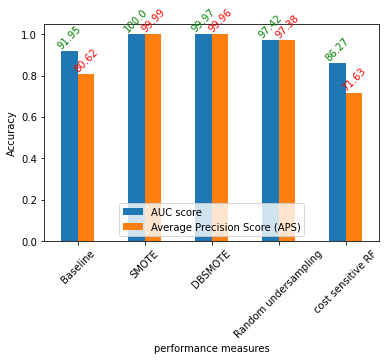

```python
compare_between_measures(["AUC score","Average Precision Score (APS)"])
```

## Refereces:

- https://machinelearningmastery.com/random-oversampling-and-undersampling-for-imbalanced-classification/
- https://towardsdatascience.com/working-with-highly-imbalanced-datasets-in-machine-learning-projects-c70c5f2a7b16
- https://www.kaggle.com/code/christiantheilhave/class-imbalance-with-weighted-random-forest/notebook
- https://smote-variants.readthedocs.io/en/latest/installation.html
- https://www.kaggle.com/code/mahmoudlimam/resampling-tutorial/notebook